# Data Reshaping

Mohammed alJaser

# Packages

```r
suppressPackageStartupMessages(library(dplyr))
suppressPackageStartupMessages(library(tidyr))
```

# Introduction

Data can be reshaped by

- transforming columns into rows
- rows into columns

This is directly combined with wide and tidy-data.

More information to be found on my [homepage](http://smartdatawithr.com/en/wide-and-tidy-data/).

```r
school_wide <- data.frame(name = c("Stuart", "Bob", "Kevin"),
             math = c(2, 3, 4),
             sport = c(3, 1, 2),
             art = c(3, 2, 1))
school_wide
```

```
##     name math sport art
## 1 Stuart    2     3   3
## 2    Bob    3     1   2
## 3  Kevin    4     2   1
```

# From Wide to Tidy-Data

If you want to transform data from wide to tidy you can use functions from package **tidyr**. The relevant function is *gather()*. You need to provide some parameters

- a key parameter name, which represents the columns. I will call the resulting column subject
- a value parameter, which will be the name of the columns holding the values
- Finally, you need to define which columns to use for transformation. Here this is 2:4.

```r
school_tidy <- school_wide %>%
    gather(key = "subject", value = "grade", 2:4)
school_tidy
```

```
##     name subject grade
## 1 Stuart    math     2
## 2    Bob    math     3
## 3  Kevin    math     4
## 4 Stuart   sport     3
## 5    Bob   sport     1
## 6  Kevin   sport     2
## 7 Stuart     art     3
## 8    Bob     art     2
## 9  Kevin     art     1
```

# From Tidy to Wide-Data

The function with the opposite effect is *spread()*. You need to pass the exact same parameters:

- key: here you define the column name of the key-column
- value: you pass the chosen name of the column with the values

```r
school_tidy %>%
  spread(key = "subject", value = "grade")
```

```
##     name art math sport
## 1    Bob   2    3     1
## 2  Kevin   1    4     2
## 3 Stuart   3    2     3
```

# Why are there two different formats?

Both have their right to exist. Wide data typically comes from other programs. Excel or SPSS usually work with wide-data.

For specific tasks it is better to transform wide-data (also called messy data) into tidy-data. I will show two examples.

## Example 1: Calculate group averages

Assume you want to calculate average class-grades per subject. With wide data you would do something like this:

```r
mean(school_wide$math)
```

```
## [1] 3
```

```r
mean(school_wide$sport)
```

```
## [1] 2
```

You repeat your code several times, which should be avoided. If there are only three columns, that is ok, but imagine you want to calculate the average for 50 columns.

Here is the solution based on tidy-data. You need to load **dplyr** package and make use of *group_by()* and *summarise()*. The code is much cleaner.

**dplyr** and **tidyr** are part of the tidyverse, which is a bunch of different packages, which rely on tidy-data.

```r
library(dplyr)
school_tidy %>%
  group_by(subject) %>%
  summarise(mean_grade = mean(grade))
```

```
## # A tibble: 3 x 2
##   subject mean_grade
##   <chr>        <dbl>
## 1 art              2
## 2 math             3
## 3 sport            2
```

## Example 2: Plotting with ggplot2

Assume you want to plot the results with ggplot2. This is done with three lines of code. Trying to get a similar representation based on wide-data will result in much more complex code.

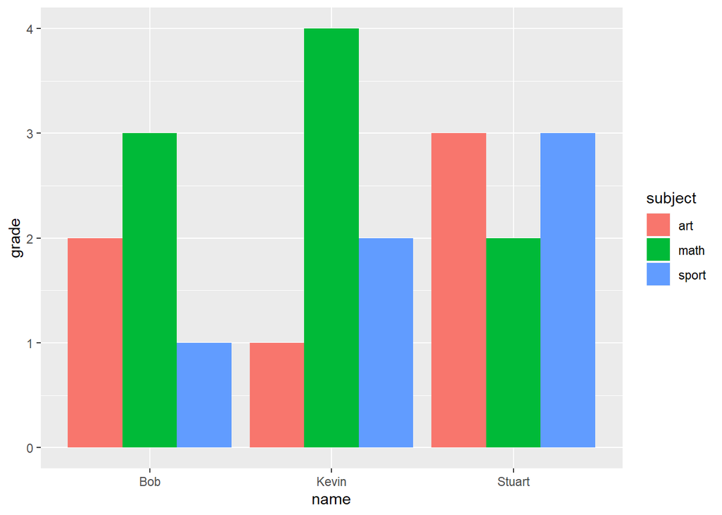

```r
library(ggplot2)
g <- ggplot(school_tidy, aes(name, grade, fill = subject))
g <- g + geom_bar(stat = "identity", position = "dodge")
g
```

# Conclusion

You have seen how easy it is to transform data from wide to tidy, and reverse. You also saw some examples in which tidy-data has advantages over wide-data.